# HW4

Samuel Negus

2025-04-22

### Summary

**Process**

This project was an expanded version of Homework 2, where I completed an in-depth search for galaxies resembling the cB58 Lyman-break galaxy. This time, about 2.5 million spectra were observed. The Center for High Throughput Computing (CHTC) was used to process 2,459 data archives with HTCondor. Using the same distance metric I implemented in HW2 (Pearson Correlation), I compiled the results into a file called hw4best100.csv containing the top 100 matches. To make transferring files easier, I created a script to extract the top 10 .fits files corresponding to the top 10 matches from hw4best100.csv. Finally, I used R to align and visualize these matches with cB58.

**Difficulties**

The main challenge I faced occurred in HW4a when I ran 5 jobs to first test my code. The 4th and 5th jobs would continually fail, until I solved this issue by making my script more selective of galaxies and dropping NA or Inf values where necessary.

Another slight problem I encountered was not noticing that I had 4 infinite distance values included at the top of hw4best100.csv that was compiled during HW4a. In HW4b, I changed my hw4merge.sh to filter out these values before selecting the best matches.

### Plotting Code

```r
rm(list=ls())
library(FITSio)
```

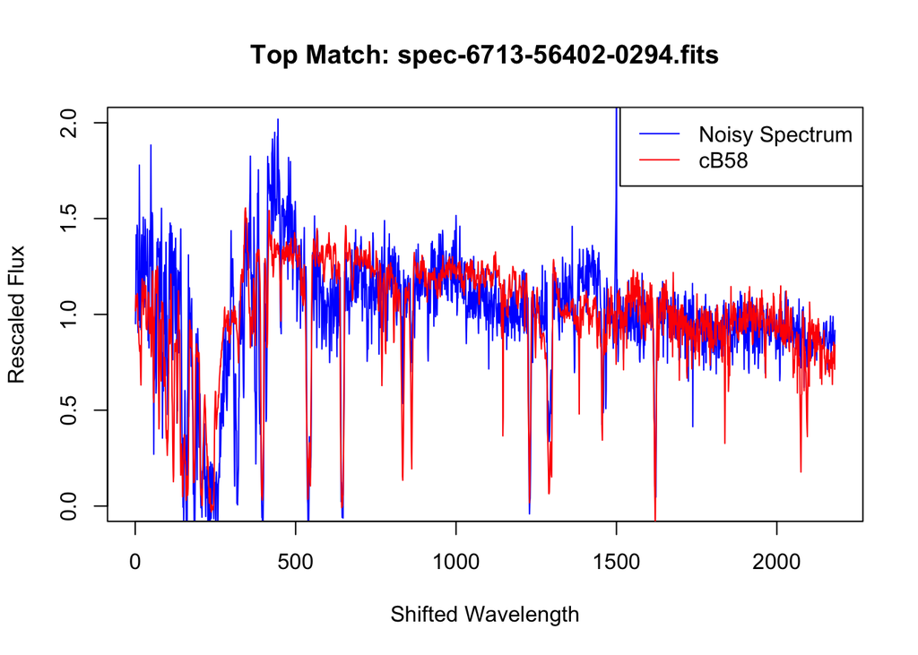

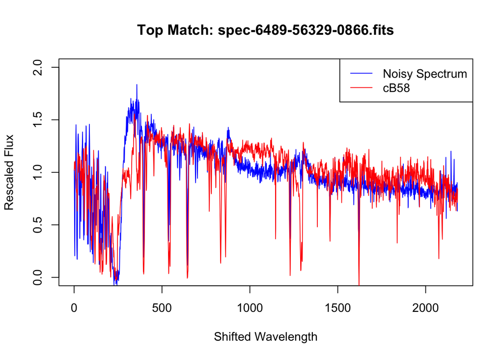

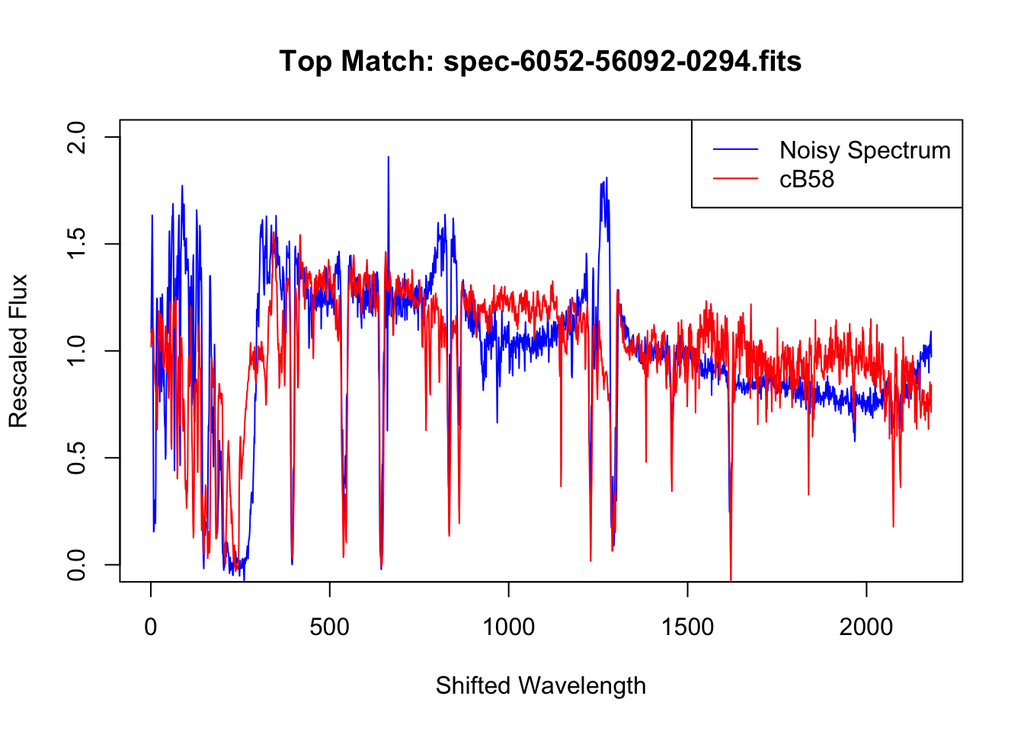

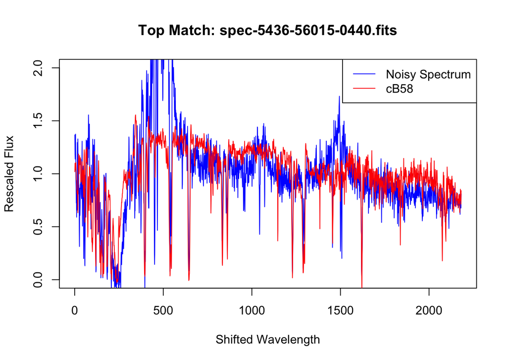

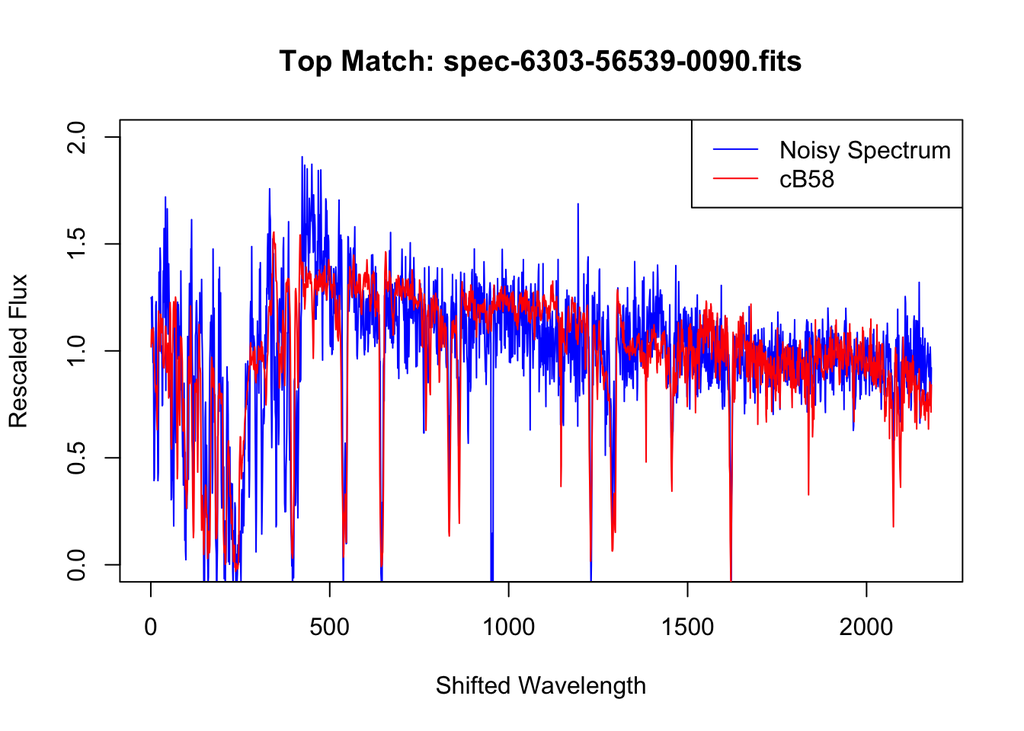

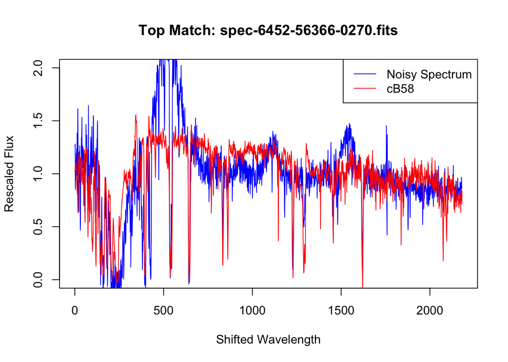

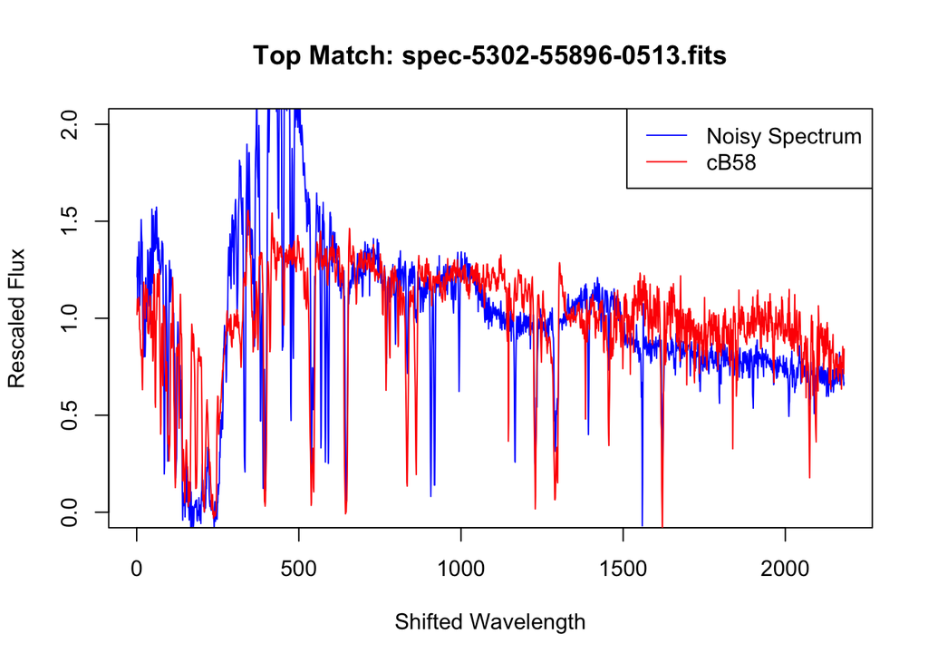

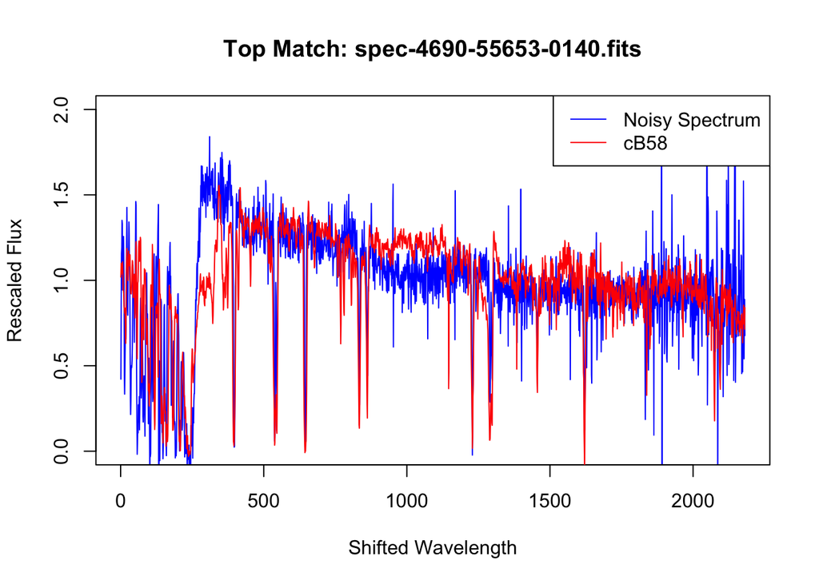

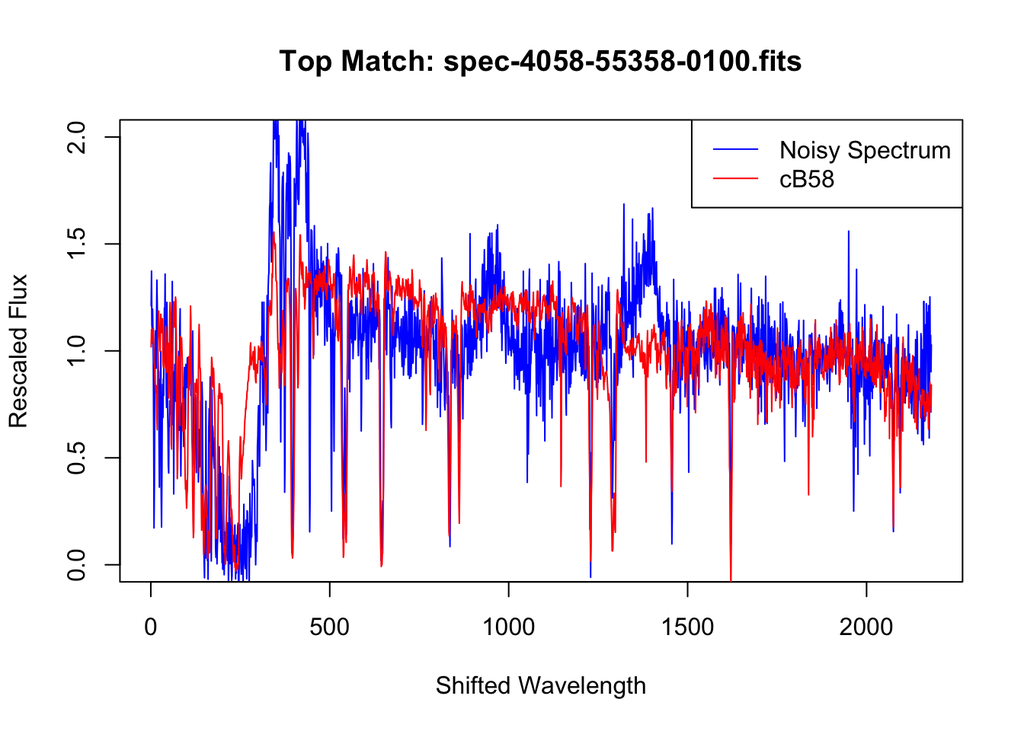

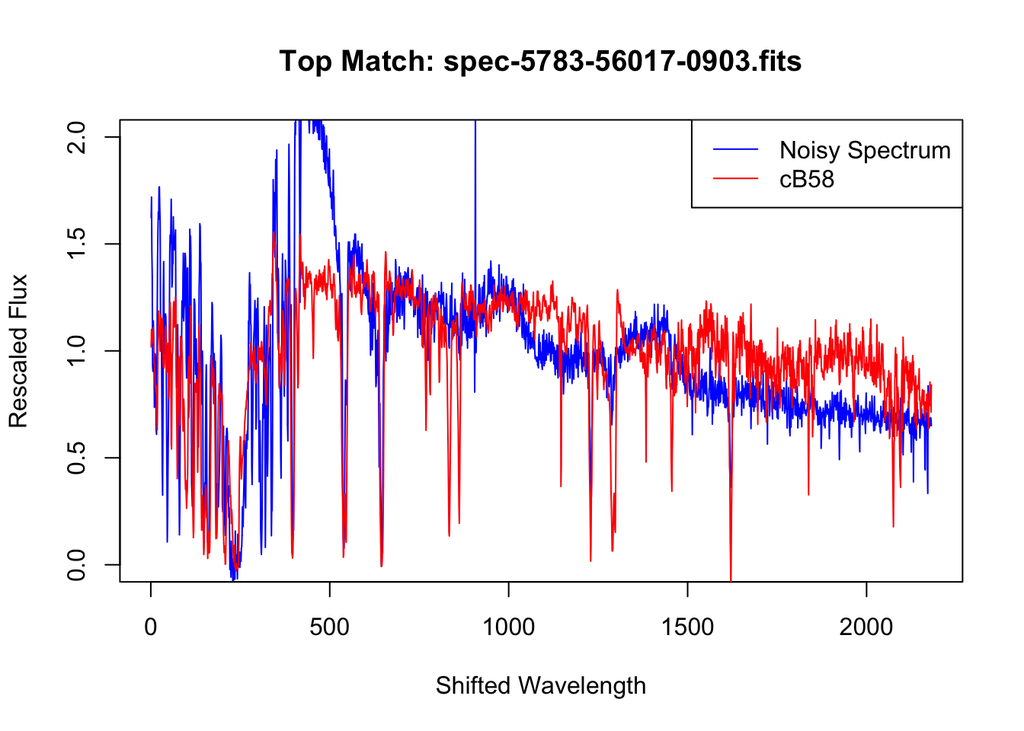

```r
top10 <- read.csv("hw4best100.csv")[1:10, ]
cB58 <- readFrameFromFITS("cB58_Lyman_break.fit")
cB58_flux <- cB58$FLUX

plot_spectrum <- function(file, i) {
  noisy <- readFrameFromFITS(file)
  noisy_flux <- noisy$flux
  aligned_flux <- noisy_flux[i:(i + length(cB58_flux) - 1)]
  scale_factor <- mean(cB58_flux, na.rm = TRUE) / mean(aligned_flux, na.rm = TRUE)
  aligned_flux <- aligned_flux * scale_factor
  min_length <- min(length(cB58_flux), length(aligned_flux))

  plot(1:min_length, aligned_flux[1:min_length], type='l', col='blue', lwd=1,
       xlab="Shifted Wavelength", ylab="Rescaled Flux",
       main = paste("Top Match:", file), ylim = c(0, 2.0))
  lines(1:min_length, cB58_flux[1:min_length], col='red', lwd=1)
  legend("topright", legend = c("Noisy Spectrum", "cB58"),
         col = c("blue", "red"), lty = 1, lwd = 1)
}

for (j in 1:10) {
  file <- top10$spectrumID[j]
  i <- top10$i[j]
  plot_spectrum(file, i)
}
```